# TFM: Estudio de los datos del conjunto de entrenamiento

#### 11.7) Cohesion Metric Rules

```
count    182671.000000
mean          0.373743
std           0.849635
min           0.000000
25%           0.000000
50%           0.000000
75%           1.000000
max          48.000000
Name: Cohesion Metric Rules, dtype: float64
Casos distintos de 0:  55183
```

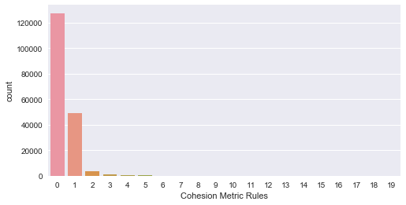

```python
lookRuleAtt("Cohesion Metric Rules")
```

#### 11.8) Comment Rules

```python
lookRuleAtt("Comment Rules")
```

```
count    182671.0
mean          0.0
std           0.0
min           0.0
25%           0.0
50%           0.0
75%           0.0
max           0.0
Name: Comment Rules, dtype: float64
Casos distintos de 0:  0
```

Al ser todos los valores 0, se puede eliminar.

```python
classes_df = classes_df.drop("Comment Rules", 1)
```

#### 11.9) Complexity Metric Rules

```
count    182671.000000
mean          0.370513
std           1.855223
min           0.000000
25%           0.000000
50%           0.000000
75%           0.000000
max         203.000000
Name: Complexity Metric Rules, dtype: float64
Casos distintos de 0:  18414
```

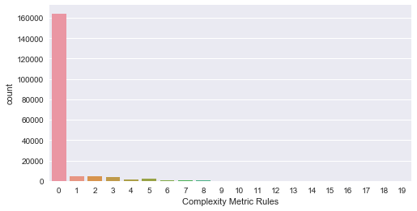

```python
lookRuleAtt("Complexity Metric Rules")
```

#### 11.10) Controversial Rules

```
count    182671.000000
mean          0.710107
std           3.275399
min           0.000000
25%           0.000000
50%           0.000000
75%           0.000000
max         296.000000
Name: Controversial Rules, dtype: float64
Casos distintos de 0:  34396
```

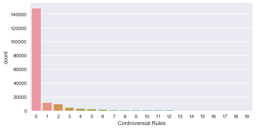

```python
lookRuleAtt("Controversial Rules")
```

#### 11.11) Coupling Metric Rules

```
count    182671.000000
mean          0.474219
std           1.780321
min           0.000000
25%           0.000000
50%           0.000000
75%           0.000000
max          80.000000
Name: Coupling Metric Rules, dtype: float64
Casos distintos de 0:  33420
```

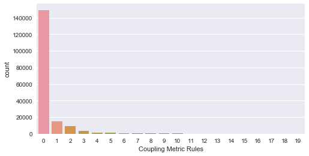

```python
lookRuleAtt("Coupling Metric Rules")
```

#### 11.12) Coupling Rules

```python
lookRuleAtt("Coupling Rules")
```

```
count    182671.0
mean          0.0
std           0.0
min           0.0
25%           0.0
50%           0.0
75%           0.0
max           0.0
Name: Coupling Rules, dtype: float64
Casos distintos de 0:  0
```

Al ser todos los valores 0, se puede eliminar esta variable.

```python
classes_df = classes_df.drop("Coupling Rules", 1)
```

#### 11.13) Design Rules

```
count    182671.000000
mean          2.093102
std           8.393986
min           0.000000
25%           0.000000
50%           0.000000
75%           2.000000
max         974.000000
Name: Design Rules, dtype: float64
Casos distintos de 0:  83506
```

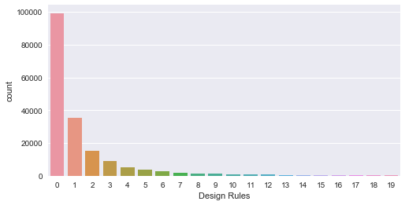

```python
lookRuleAtt("Design Rules")
```

#### 11.14) Documentation Metric Rules

```
count    182671.000000
mean         16.247461
std          26.553757
min           0.000000
25%           5.000000
50%           9.000000
75%          17.000000
max        1435.000000
Name: Documentation Metric Rules, dtype: float64
Casos distintos de 0:  180230
```

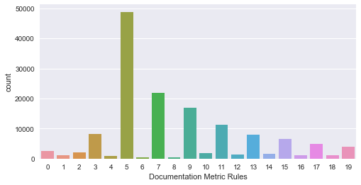

```python
lookRuleAtt("Documentation Metric Rules")
```

Este tipo de reglas sigue una distribución diferente a las que hemos visto hasta ahora.

#### 11.15) Empty Code Rules

```python
lookRuleAtt("Empty Code Rules")
```

```
count    182671.000000
mean          0.040116
std           0.617920
min           0.000000
25%           0.000000
50%           0.000000
75%           0.000000
max         150.000000
Name: Empty Code Rules, dtype: float64
Casos distintos de 0:  3601
```

Al haber tan pocos casos distintos de 0, se puede eliminar.

```python
classes_df = classes_df.drop("Empty Code Rules", 1)
```

#### 11.16) Finalizer Rules

```python
lookRuleAtt("Finalizer Rules")
```

```
count    182671.000000
mean          0.000422
std           0.031475
min           0.000000
25%           0.000000
50%           0.000000
75%           0.000000
max           7.000000
Name: Finalizer Rules, dtype: float64
Casos distintos de 0:  56
```

Al haber tan pocos casos distintos de 0 se puede eliminar.

```python
classes_df = classes_df.drop("Finalizer Rules", 1)
```

#### 11.17) Import Statement Rules

```python
lookRuleAtt("Import Statement Rules")
```

```
count    182671.000000
mean          0.064898
std           1.248128
min           0.000000
25%           0.000000
50%           0.000000
75%           0.000000
max         102.000000
Name: Import Statement Rules, dtype: float64
Casos distintos de 0:  2854
```

Al haber tan pocos casos distintos de 0 se puede eliminar.

```python
classes_df = classes_df.drop("Import Statement Rules", 1)
```

#### 11.18) Inheritance Metric Rules

```
count    182671.000000
mean          0.122603
std           0.850055
min           0.000000
25%           0.000000
50%           0.000000
75%           0.000000
max         146.000000
Name: Inheritance Metric Rules, dtype: float64
Casos distintos de 0:  16156
```

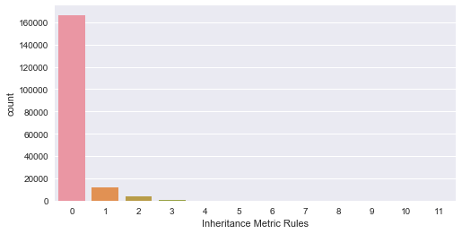

```python
lookRuleAtt("Inheritance Metric Rules")
```

#### 11.19) J2EE Rules

```python
lookRuleAtt("J2EE Rules")
```

```
count    182671.000000
mean          0.003164
std           0.078866
min           0.000000
25%           0.000000
50%           0.000000
75%           0.000000
max           6.000000
Name: J2EE Rules, dtype: float64
Casos distintos de 0:  406
```

Hay muy pocos casos distintos de 0, se podría eliminar.

```python
classes_df = classes_df.drop("J2EE Rules", 1)
```

#### 11.20) JUnit Rules

```
count    182671.000000
mean          1.272123
std          18.448408
min           0.000000
25%           0.000000
50%           0.000000
75%           0.000000
max        2320.000000
Name: JUnit Rules, dtype: float64
Casos distintos de 0:  18760
```

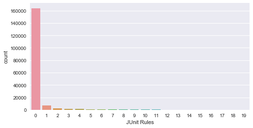

```python
lookRuleAtt("JUnit Rules")
```

#### 11.21) Jakarta Commons Logging Rules

```python
lookRuleAtt("Jakarta Commons Logging Rules")
```

```
count    182671.000000
mean          0.039776
std           0.432509
min           0.000000
25%           0.000000
50%           0.000000
75%           0.000000
max          17.000000
Name: Jakarta Commons Logging Rules, dtype: float64
Casos distintos de 0:  3103
```

Hay muy pocos valores distintos de 0, se puede eliminar.

```python
classes_df = classes_df.drop("Jakarta Commons Logging Rules", 1)
```

#### 11.22) Java Logging Rules

```python
lookRuleAtt("Java Logging Rules")
```

```
count    182671.000000
mean          0.141046
std           1.160034
min           0.000000
25%           0.000000
50%           0.000000
75%           0.000000
max          62.000000
Name: Java Logging Rules, dtype: float64
Casos distintos de 0:  8605
```

Hay muy pocos casos distintos de 0, se podría eliminar.

```python
classes_df = classes_df.drop("Java Logging Rules", 1)
```

#### 11.23) JavaBean Rules

```python
lookRuleAtt("JavaBean Rules")
```

```
count    182671.000000
mean          0.014534
std           0.159178
min           0.000000
25%           0.000000
50%           0.000000
75%           0.000000
max          17.000000
Name: JavaBean Rules, dtype: float64
Casos distintos de 0:  2207
```

Hay muy pocos casos distintos de 0, se podrían eliminar.

```python
classes_df = classes_df.drop("JavaBean Rules", 1)
```

#### 11.24) MigratingToJUnit4 Rules

```python
lookRuleAtt("MigratingToJUnit4 Rules")
```

```
count    182671.0
mean          0.0
std           0.0
min           0.0
25%           0.0
50%           0.0
75%           0.0
max           0.0
Name: MigratingToJUnit4 Rules, dtype: float64
Casos distintos de 0:  0
```

Todos los valores son 0, hay que eliminar la variable.

```python
classes_df = classes_df.drop("MigratingToJUnit4 Rules", 1)
```

#### 11.25) Migration Rules

```python
lookRuleAtt("Migration Rules")
```

```
count    182671.000000
mean          0.064241
std           6.162568
min           0.000000
25%           0.000000
50%           0.000000
75%           0.000000
max         980.000000
Name: Migration Rules, dtype: float64
Casos distintos de 0:  711
```

Hay muy pocos valores con un valor distinto de 0, se podría eliminar.

```python
classes_df = classes_df.drop("Migration Rules", 1)
```

#### 11.26) Migration13 Rules

```python
lookRuleAtt("Migration13 Rules")
```

```
count    182671.0
mean          0.0
std           0.0
min           0.0
25%           0.0
50%           0.0
75%           0.0
max           0.0
Name: Migration13 Rules, dtype: float64
Casos distintos de 0:  0
```

Todos los valores son 0, se puede eliminar.

```python
classes_df = classes_df.drop("Migration13 Rules", 1)
```

#### 11.27) Migration14 Rules

```python
lookRuleAtt("Migration14 Rules")
```

```
count    182671.0
mean          0.0
std           0.0
min           0.0
25%           0.0
50%           0.0
75%           0.0
max           0.0
Name: Migration14 Rules, dtype: float64
Casos distintos de 0:  0
```

Todos los valores son 0, se pueden eliminar.

```python
classes_df = classes_df.drop("Migration14 Rules", 1)
```

#### 11.28) Migration15 Rules

```python
lookRuleAtt("Migration15 Rules")
```

```
count    182671.0
mean          0.0
std           0.0
min           0.0
25%           0.0
50%           0.0
75%           0.0
max           0.0
Name: Migration15 Rules, dtype: float64
Casos distintos de 0:  0
```

Todos los valores son 0, se pueden eliminar.

```python
classes_df = classes_df.drop("Migration15 Rules", 1)
```

#### 11.29) Naming Rules

```
count    182671.000000
mean          0.537918
std           3.168406
min           0.000000
25%           0.000000
50%           0.000000
75%           0.000000
max         727.000000
Name: Naming Rules, dtype: float64
Casos distintos de 0:  29202
```

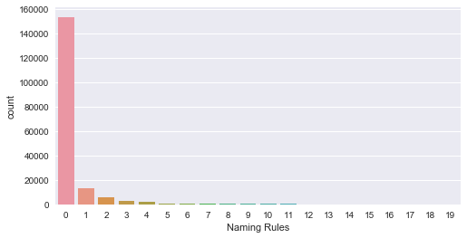

```python
lookRuleAtt("Naming Rules")
```

#### 11.30) Optimization Rules

```
count    182671.000000
mean          0.144703
std           0.872831
min           0.000000
25%           0.000000
50%           0.000000
75%           0.000000
max          58.000000
Name: Optimization Rules, dtype: float64
Casos distintos de 0:  12629
```

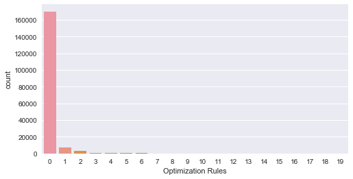

```python
lookRuleAtt("Optimization Rules")
```

#### 11.31) Security Code Guideline Rules

```python
lookRuleAtt("Security Code Guideline Rules")
```

```
count    182671.000000
mean          0.059035
std           0.427777
min           0.000000
25%           0.000000
50%           0.000000
75%           0.000000
max          20.000000
Name: Security Code Guideline Rules, dtype: float64
Casos distintos de 0:  5478
```

Hay muy pocos casos, podemos eliminar esta variable.

```python
classes_df = classes_df.drop("Security Code Guideline Rules", 1)
```

#### 11.32) Size Metric Rules

```
count    182671.000000
mean          1.812970
std           4.613155
min           0.000000
25%           0.000000
50%           0.000000
75%           2.000000
max         364.000000
Name: Size Metric Rules, dtype: float64
Casos distintos de 0:  66108
```

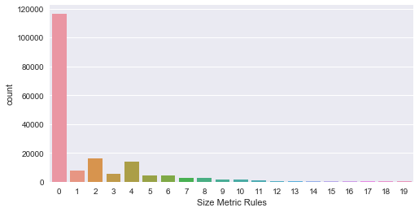

```python
lookRuleAtt("Size Metric Rules")
```

#### 11.33) Strict Exception Rules

```
count    182671.000000
mean          0.291573
std           1.986477
min           0.000000
25%           0.000000
50%           0.000000
75%           0.000000
max         201.000000
Name: Strict Exception Rules, dtype: float64
Casos distintos de 0:  21831
```

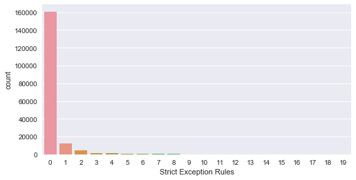

```python
lookRuleAtt("Strict Exception Rules")
```

#### 11.34) String and StringBuffer Rules

```
count    182671.000000
mean          0.348583
std          10.201343
min           0.000000
25%           0.000000
50%           0.000000
75%           0.000000
max        4264.000000
Name: String and StringBuffer Rules, dtype: float64
Casos distintos de 0:  14911
```

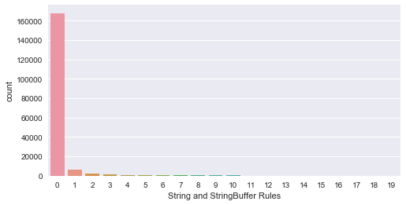

```python
lookRuleAtt("String and StringBuffer Rules")
```

#### 11.35) Type Resolution Rules

```
count    182671.000000
mean          0.441044
std           2.172022
min           0.000000
25%           0.000000
50%           0.000000
75%           0.000000
max         113.000000
Name: Type Resolution Rules, dtype: float64
Casos distintos de 0:  27268
```

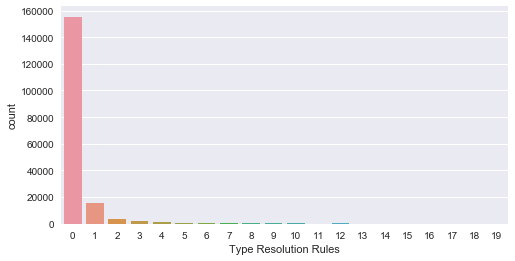

```python
lookRuleAtt("Type Resolution Rules")
```

#### 11.36) Unnecessary and Unused Code Rules

```python
lookRuleAtt("Unnecessary and Unused Code Rules")
```

```
count    182671.000000
mean          0.196107
std           6.257042
min           0.000000
25%           0.000000
50%           0.000000
75%           0.000000
max         941.000000
Name: Unnecessary and Unused Code Rules, dtype: float64
Casos distintos de 0:  7428
```

Muy pocos casos, podemos descartar la variable.

```python
classes_df = classes_df.drop("Unnecessary and Unused Code Rules", 1)
```

#### 11.37) Vulnerability Rules

```python
lookRuleAtt("Vulnerability Rules")
```

```
count    182671.000000
mean          0.000066
std           0.008105
min           0.000000
25%           0.000000
50%           0.000000
75%           0.000000
max           1.000000
Name: Vulnerability Rules, dtype: float64
Casos distintos de 0:  12
```

Al haber solo 12 casos podemos eliminar la variable.

```python
classes_df = classes_df.drop("Vulnerability Rules", 1)
```

#### Resumen medidas de violaciones de reglas

Lo que se puede ver como regla general es que la gran mayoría de todos los casos son 0. Igual se pueden binarizar las variables o bien crear una variable construida a partir de todas ellas con una unión lógica, para indicar si viola alguna regla o no, en lugar de indicar el tipo del error y el número de errores como hasta ahora.

### 12) Conclusiones

```python
print("Número de variables final: ", len(classes_df.columns) - 1)
```

```
Número de variables final:  71
```

### 13) Atributos más representativos

```python
classes_df.corr()['Has bugs'].sort_values(ascending=False)[1:25]
```

```
CBO                           0.214950
NLE                           0.203398
RFC                           0.202729
NOI                           0.195109
NL                            0.181211
Complexity Metric Rules       0.164763
WMC                           0.161878
TNLM                          0.156400
Documentation Metric Rules    0.152558
NLM                           0.150157
Coupling Metric Rules         0.140169
TNLA                          0.138305
NLA                           0.132549
WarningInfo                   0.127178
Size Metric Rules             0.122586
LOC                           0.121445
PUA                           0.114943
TNA                           0.111586
Design Rules                  0.103692
TNLG                          0.098677
NLG                           0.097845
NOS                           0.096993
NA                            0.094582
NOA                           0.094003
Name: Has bugs, dtype: float64
```

Para seleccionar las variables para mostrar al usuario tendremos en cuenta como primer factor la correlación con la variable clase (para enseñar aquellas que sean útiles de cara a ver si hay bugs o no) y como segundo la diferencia entre lo que trata de expresar cada variable. Por ejemplo, las variables NLE y NL representan casi lo mismo, grado de anidación, por lo que con una de ellas es suficiente. En base a eso las variables que vamos a escoger son:

- CBO
- NLE
- RFC
- Complexity Metric Rules
- WMC
- Documentation Metric Rules
- Coupling Metric Rules
- TNLA
- Warning Info
- Size Metrics Rules